# ML Course Prediction Assigment

Esteban R. Freyre

December 21th, 2018

### Background

Using devices such as Jawbone Up, Nike FuelBand, and Fitbit it is now possible to collect a large amount of data about personal activity relatively inexpensively. These type of devices are part of the quantified self movement. The goal of the project is to predict the manner in which they did the exercise. This is the “classe” variable in the training set.

The data for this project come from this source: http://groupware.les.inf.puc-rio.br/har.

Download Data Sets

```r
training_0<-"https://d396qusza40orc.cloudfront.net/predmachlearn/pml-training.csv"
validation_0<-"https://d396qusza40orc.cloudfront.net/predmachlearn/pml-testing.csv"

download.file(training_0,destfile = "/home/sunshine/training_0.csv",method = "curl")
download.file(validation_0,destfile = "/home/sunshine/validation_0.csv",method = "curl")

dateDownloaded<-date()

training_0<-read.csv("/home/sunshine/training_0.csv",sep = ",",header = TRUE)
validation_0<-read.csv("/home/sunshine/validation_0.csv",sep = ",",header = TRUE)
```

### Data Cleaning and Exploration

```
## 'data.frame':    19622 obs. of  160 variables:
##  $ X                       : int  1 2 3 4 5 6 7 8 9 10 ...
##  $ user_name               : Factor w/ 6 levels "adelmo","carlitos",..: 2 2 2 2 2 2 2 2 2 2 ...
##  $ raw_timestamp_part_1    : int  1323084231 1323084231 1323084231 1323084232 1323084232 1323084232 1323084232 1323084232 1323084232 1323084232 ...
##  $ raw_timestamp_part_2    : int  788290 808298 820366 120339 196328 304277 368296 440390 484323 484434 ...
##  $ cvtd_timestamp          : Factor w/ 20 levels "02/12/2011 13:32",..: 9 9 9 9 9 9 9 9 9 9 ...
##  $ new_window              : Factor w/ 2 levels "no","yes": 1 1 1 1 1 1 1 1 1 1 ...
##  $ num_window              : int  11 11 11 12 12 12 12 12 12 12 ...
##  $ roll_belt               : num  1.41 1.41 1.42 1.48 1.48 1.45 1.42 1.42 1.43 1.45 ...
##  $ pitch_belt              : num  8.07 8.07 8.07 8.05 8.07 8.06 8.09 8.13 8.16 8.17 ...
##  $ yaw_belt                : num  -94.4 -94.4 -94.4 -94.4 -94.4 -94.4 -94.4 -94.4 -94.4 -94.4 ...
##  $ total_accel_belt        : int  3 3 3 3 3 3 3 3 3 3 ...
##  $ kurtosis_roll_belt      : Factor w/ 397 levels "","-0.016850",..: 1 1 1 1 1 1 1 1 1 1 ...
##  $ kurtosis_picth_belt     : Factor w/ 317 levels "","-0.021887",..: 1 1 1 1 1 1 1 1 1 1 ...
##  $ kurtosis_yaw_belt       : Factor w/ 2 levels "","#DIV/0!": 1 1 1 1 1 1 1 1 1 1 ...
```

[output cut: 86 more lines]

There is some cleaning to be done for those characters variables, check for zero variance variables and preparing data for partioning training and test.

```r
training_0<- training_0[, colSums(is.na(training_0)) == 0] # remove NA values
validation_0 <- validation_0[, colSums(is.na(validation_0)) == 0] # remove NA values
```

There are character columns and data not meaningful as predictors to be removed

```r
classe<-training_0$classe
training_del<-grepl("^X|timestamp|window", names(training_0)) #variables not meaningful as predictors
training_1<-training_0[, !training_del]
training_2<-training_1[, sapply(training_1,is.numeric)] # variables to be changed as numeric
training_2$classe<-classe

validation_del <- grepl("^X|timestamp|window|problem_id", names(validation_0)) # variables not meaningful as predictors
validation_1<-validation_0[, !validation_del]
validation_2<-validation_1[, sapply(validation_1,is.numeric)] # variables to be changed as numeric
```

```r
library(caret)
```

Verifying changes madde for near zero variance predictors

```r
zerovar_2<-nearZeroVar(training_2,saveMetrics= TRUE, names=TRUE, allowParallel = TRUE)
summary(zerovar_2) # there are no more nzv
```

```
##    freqRatio      percentUnique       zeroVar           nzv
##  Min.   : 1.000   Min.   : 0.02548   Mode :logical   Mode :logical
##  1st Qu.: 1.036   1st Qu.: 1.41678   FALSE:53        FALSE:53
##  Median : 1.079   Median : 3.27693
##  Mean   : 6.002   Mean   : 8.88241
##  3rd Qu.: 1.140   3rd Qu.: 7.76679
##  Max.   :87.256   Max.   :84.20650
```

```r
summary(training_2) # check changes
```

```
##    roll_belt        pitch_belt          yaw_belt       total_accel_belt
##  Min.   :-28.90   Min.   :-55.8000   Min.   :-180.00   Min.   : 0.00
##  1st Qu.:  1.10   1st Qu.:  1.7600   1st Qu.: -88.30   1st Qu.: 3.00
##  Median :113.00   Median :  5.2800   Median : -13.00   Median :17.00
##  Mean   : 64.41   Mean   :  0.3053   Mean   : -11.21   Mean   :11.31
##  3rd Qu.:123.00   3rd Qu.: 14.9000   3rd Qu.:  12.90   3rd Qu.:18.00
##  Max.   :162.00   Max.   : 60.3000   Max.   : 179.00   Max.   :29.00
##   gyros_belt_x        gyros_belt_y       gyros_belt_z
##  Min.   :-1.040000   Min.   :-0.64000   Min.   :-1.4600
##  1st Qu.:-0.030000   1st Qu.: 0.00000   1st Qu.:-0.2000
##  Median : 0.030000   Median : 0.02000   Median :-0.1000
##  Mean   :-0.005592   Mean   : 0.03959   Mean   :-0.1305
##  3rd Qu.: 0.110000   3rd Qu.: 0.11000   3rd Qu.:-0.0200
##  Max.   : 2.220000   Max.   : 0.64000   Max.   : 1.6200
##   accel_belt_x       accel_belt_y     accel_belt_z     magnet_belt_x
##  Min.   :-120.000   Min.   :-69.00   Min.   :-275.00   Min.   :-52.0
##  1st Qu.: -21.000   1st Qu.:  3.00   1st Qu.:-162.00   1st Qu.:  9.0
##  Median : -15.000   Median : 35.00   Median :-152.00   Median : 35.0
##  Mean   :  -5.595   Mean   : 30.15   Mean   : -72.59   Mean   : 55.6
##  3rd Qu.:  -5.000   3rd Qu.: 61.00   3rd Qu.:  27.00   3rd Qu.: 59.0
##  Max.   :  85.000   Max.   :164.00   Max.   : 105.00   Max.   :485.0
##  magnet_belt_y   magnet_belt_z       roll_arm         pitch_arm
##  Min.   :354.0   Min.   :-623.0   Min.   :-180.00   Min.   :-88.800
##  1st Qu.:581.0   1st Qu.:-375.0   1st Qu.: -31.77   1st Qu.:-25.900
##  Median :601.0   Median :-320.0   Median :   0.00   Median :  0.000
##  Mean   :593.7   Mean   :-345.5   Mean   :  17.83   Mean   : -4.612
##  3rd Qu.:610.0   3rd Qu.:-306.0   3rd Qu.:  77.30   3rd Qu.: 11.200
##  Max.   :673.0   Max.   : 293.0   Max.   : 180.00   Max.   : 88.500
##     yaw_arm          total_accel_arm  gyros_arm_x        gyros_arm_y
##  Min.   :-180.0000   Min.   : 1.00   Min.   :-6.37000   Min.   :-3.4400
##  1st Qu.: -43.1000   1st Qu.:17.00   1st Qu.:-1.33000   1st Qu.:-0.8000
##  Median :   0.0000   Median :27.00   Median : 0.08000   Median :-0.2400
##  Mean   :  -0.6188   Mean   :25.51   Mean   : 0.04277   Mean   :-0.2571
##  3rd Qu.:  45.8750   3rd Qu.:33.00   3rd Qu.: 1.57000   3rd Qu.: 0.1400
##  Max.   : 180.0000   Max.   :66.00   Max.   : 4.87000   Max.   : 2.8400
##   gyros_arm_z       accel_arm_x       accel_arm_y      accel_arm_z
##  Min.   :-2.3300   Min.   :-404.00   Min.   :-318.0   Min.   :-636.00
##  1st Qu.:-0.0700   1st Qu.:-242.00   1st Qu.: -54.0   1st Qu.:-143.00
##  Median : 0.2300   Median : -44.00   Median :  14.0   Median : -47.00
##  Mean   : 0.2695   Mean   : -60.24   Mean   :  32.6   Mean   : -71.25
```

[output cut: 50 more lines]

```
##  Max.   :311.00000   Max.   :231.0000   Max.   : 477.00   Max.   : 923.0
##  accel_forearm_z   magnet_forearm_x  magnet_forearm_y magnet_forearm_z
##  Min.   :-446.00   Min.   :-1280.0   Min.   :-896.0   Min.   :-973.0
##  1st Qu.:-182.00   1st Qu.: -616.0   1st Qu.:   2.0   1st Qu.: 191.0
##  Median : -39.00   Median : -378.0   Median : 591.0   Median : 511.0
##  Mean   : -55.29   Mean   : -312.6   Mean   : 380.1   Mean   : 393.6
##  3rd Qu.:  26.00   3rd Qu.:  -73.0   3rd Qu.: 737.0   3rd Qu.: 653.0
##  Max.   : 291.00   Max.   :  672.0   Max.   :1480.0   Max.   :1090.0
##  classe
##  A:5580
##  B:3797
##  C:3422
##  D:3216
##  E:3607
##
```

### Use of Cross validation

After partitioning data for training and testing using 70/30 percent for training and testing respectively some models will be fitted. Eventually the validation data set is the one already downloaded with 20 observations and will be used only once to avoid overfitting. A comparison of predictions among models is found at the conclusion of the report.

For reasons of little computational power only a handful of models will be shown when originally more were tested. Too many challenges were met when knitting the report. Thus in order to meet course deadlines and considering ${Knitr}$ limitations for complex computations the original more comprehensive report was discarded. Nevertheless similar results are achieved boostraping with trees and k-Nearest Neighbors than those obtained with Random Forest and Gradient Boosting (GBM).

```r
set.seed(32343)
inTrain <- createDataPartition(y=training_2$classe, p=0.70, list=F)
Train <- training_2[inTrain, ]
Test<- training_2[-inTrain, ]
```

Dimensions of original and training dataset comparison

```
##                   [,1] [,2]
## original dataset 19622   53
## training set     13737   53
## testing set       5885   53
## validation          20   52
```

Principal Component Analysis

```
## Importance of first k=25 (out of 52) components:
##                             PC1      PC2      PC3      PC4       PC5
## Standard deviation     599.1472 534.2298 467.3602 378.0503 356.77777
## Proportion of Variance   0.2639   0.2098   0.1606   0.1051   0.09357
## Cumulative Proportion    0.2639   0.4737   0.6342   0.7393   0.83288
##                             PC6       PC7       PC8       PC9      PC10
## Standard deviation     255.8081 201.38385 173.45982 157.84870 118.58821
## Proportion of Variance   0.0481   0.02981   0.02212   0.01832   0.01034
## Cumulative Proportion    0.8810   0.91080   0.93291   0.95123   0.96157
##                            PC11     PC12     PC13     PC14    PC15
## Standard deviation     96.79780 89.51753 76.38332 68.85558 62.8422
## Proportion of Variance  0.00689  0.00589  0.00429  0.00349  0.0029
## Cumulative Proportion   0.96846  0.97435  0.97863  0.98212  0.9850
##                            PC16     PC17     PC18     PC19     PC20
## Standard deviation     56.87016 53.02871 49.68040 48.74659 41.36430
## Proportion of Variance  0.00238  0.00207  0.00181  0.00175  0.00126
## Cumulative Proportion   0.98740  0.98947  0.99128  0.99303  0.99429
##                            PC21    PC22    PC23     PC24     PC25
## Standard deviation     37.80795 34.9525 33.0682 30.57602 25.25032
## Proportion of Variance  0.00105  0.0009  0.0008  0.00069  0.00047
## Cumulative Proportion   0.99534  0.9962  0.9970  0.99773  0.99820
```

### Exploratory Plotting

```r
library(GGally)
```

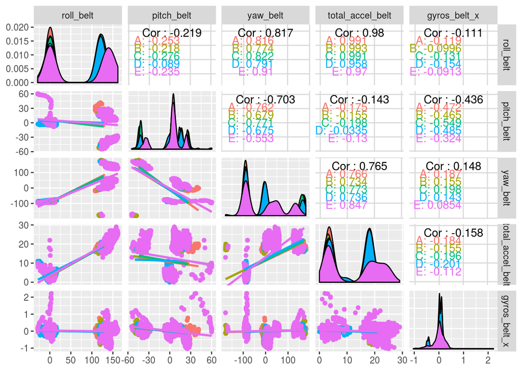

### Strategy for models and samples in training

The preferable method for sampling will be boostraping with correction for replacement to avoid bias. There are predictors with high variance and with negative values thus some transformations will be made in most cases YeoJohnson.

### Setting up parallelization

```r
library(doParallel)
cl <- makePSOCKcluster(4)
registerDoParallel(cl)
```

### Data Modeling

```r
library(MASS)
TCtrl_lda<-trainControl(method = "boot632",search="random",allowParallel = TRUE)
set.seed(32343)
model_lda<-train(classe ~ .,method="lda",data=Train,preProcess = "YeoJohnson",tuneLength = 12, trControl = TCtrl_lda)
model_lda
```

```
## Linear Discriminant Analysis
##
## 13737 samples
##    52 predictor
##     5 classes: 'A', 'B', 'C', 'D', 'E'
##
## Pre-processing: Yeo-Johnson transformation (52)
## Resampling: Bootstrapped (25 reps)
## Summary of sample sizes: 13737, 13737, 13737, 13737, 13737, 13737, ...
## Resampling results:
##
##   Accuracy   Kappa
##   0.7055579  0.6274669
```

```r
pre_lda<-predict.train(model_lda,newdata=Test)
errortestlda <- 1 - as.numeric(confusionMatrix(Test$classe, pre_lda)$overall[1])
```

It is found Gausian predictors do not perform good, which it makes sence since we face a multiclass classification problem and it is more suitable for non parametric boundaries classifications.

In this example a model tree have high variance due to the correlation in the predictors. Following a Bagging model will be pursued, finding that it succeeds in reducing the variance and hence the test error of unstable procedures like trees. Therefore the improvement is made in prediction by increasing the number of boostrap samples and computing their corresponding estimator. We should use large trees for bagging, because the variance reduction due to bagging asks for a large tree to balance the bias-variance trade-off.

```r
ctrol_bag1 <- trainControl(method="boot632",search="random",allowParallel = TRUE)

set.seed(32343)
model_bag1<-train(x=Train[1:52],y=Train$classe, method="treebag",preProcess= "YeoJohnson",trControl=ctrol_bag1,tuneLength=15)
model_bag1
```

```
## Bagged CART
##
## 13737 samples
##    52 predictor
##     5 classes: 'A', 'B', 'C', 'D', 'E'
##
## Pre-processing: Yeo-Johnson transformation (51)
## Resampling: Bootstrapped (25 reps)
## Summary of sample sizes: 13737, 13737, 13737, 13737, 13737, 13737, ...
## Resampling results:
##
##   Accuracy  Kappa
##   0.98727   0.9838881
```

```r
pre_bag1<-predict.train(model_bag1,newdata=Test)
errortestbag1 <- 1 - as.numeric(confusionMatrix(Test$classe, pre_bag1)$overall[1])
```

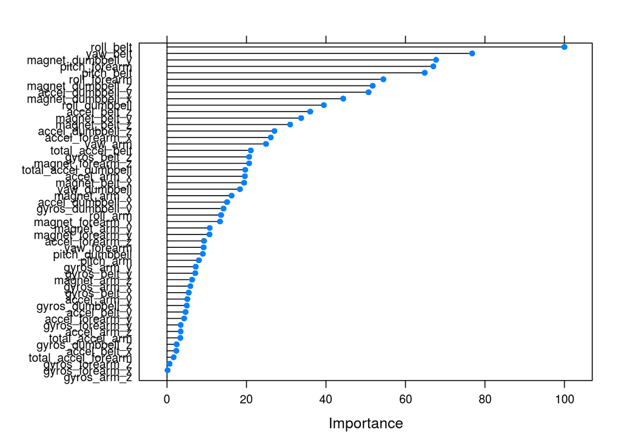

```r
bag1Imp <- varImp(model_bag1)
plot(bag1Imp)
```

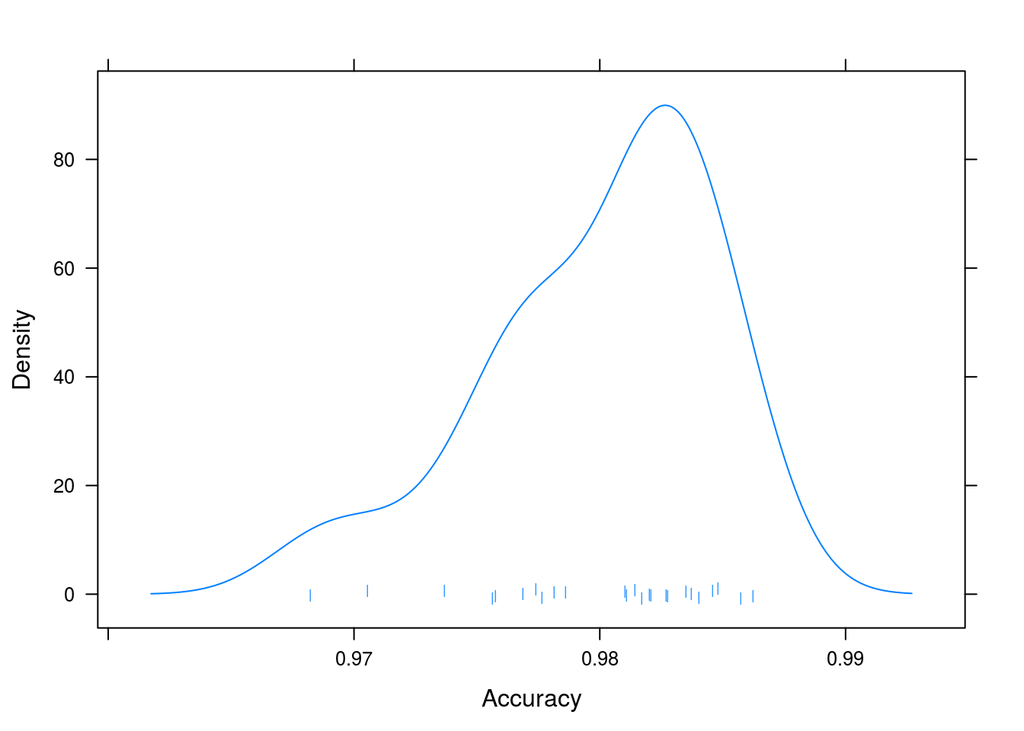

```r
densityplot(model_bag1, pch = "|")
```

k-Nearest Neighbors

```r
TCtrlknn<-trainControl(method = "boot632",allowParallel = FALSE)
set.seed(32343)
model_knn<-train(classe ~ ., data=Train,method="knn",preProcess = "YeoJohnson",trControl = TCtrlknn) # using preprocessing with YeoJohnson transformation because of the negative values some predictors have.
model_knn
```

```
## k-Nearest Neighbors
##
## 13737 samples
##    52 predictor
##     5 classes: 'A', 'B', 'C', 'D', 'E'
##
## Pre-processing: Yeo-Johnson transformation (52)
## Resampling: Bootstrapped (25 reps)
## Summary of sample sizes: 13737, 13737, 13737, 13737, 13737, 13737, ...
## Resampling results across tuning parameters:
##
##   k  Accuracy   Kappa
##   5  0.9022000  0.8762203
##   7  0.8837020  0.8527933
##   9  0.8667687  0.8313294
##
## Accuracy was used to select the optimal model using the largest value.
## The final value used for the model was k = 5.
```

```r
pre_knn<-predict.train(model_knn,newdata=Test)
errortestknn <- 1 - as.numeric(confusionMatrix(Test$classe, pre_knn)$overall[1])
```

```r
compare_results<-list(rbind(BAG=errortestbag1,KNN=errortestknn,LDA=errortestlda))
compare_results
```

```
## [[1]]
##           [,1]
## BAG 0.01002549
## KNN 0.09158879
## LDA 0.30263381
```

Bagged CART provides the smaller out of sample error 0.0100255 considering the test sample. It is followed by k-Nearest Neighbors with 0.0915888. If a Random Forest model where fitted, it would provide an extension of Bagging on Classification/regression trees. Random Forest improves on bagging by reducing the correlation between the sampled trees.

### Predicting for Validation Data Set with chosen model

Algo is applied to the validation data previusly cleaned.

```r
set.seed(32343)
validatingbag1<-summary(predict.train(model_bag1, newdata=validation_2))

set.seed(32343)
validatingknn<-summary(predict.train(model_knn, newdata=validation_2))

set.seed(32343)
validatinglda<-summary(predict.train(model_lda, newdata=validation_2))

compare_validations<-list(rbind(validatingbag1,validatingknn,validatinglda))
compare_validations
```

```
## [[1]]
##                A B C D E
## validatingbag1 7 8 1 1 3
## validatingknn  7 7 1 2 3
## validatinglda  7 6 2 3 2
```

## Apendix and Supporting Data

### Data exploration

```r
library(dplyr)
subsetroll<-select(Train,starts_with("roll"))
summary(subsetroll)
```

```
##    roll_belt         roll_arm       roll_dumbbell      roll_forearm
##  Min.   :-28.80   Min.   :-180.00   Min.   :-153.51   Min.   :-180.00
##  1st Qu.:  1.09   1st Qu.: -30.90   1st Qu.: -17.36   1st Qu.:  -0.81
##  Median :113.00   Median :   0.00   Median :  48.17   Median :  21.90
##  Mean   : 64.13   Mean   :  18.25   Mean   :  24.09   Mean   :  33.62
##  3rd Qu.:123.00   3rd Qu.:  77.40   3rd Qu.:  67.60   3rd Qu.: 140.00
##  Max.   :162.00   Max.   : 180.00   Max.   : 153.55   Max.   : 180.00
```

# Using the heatmap function in order to find patterns and covariances

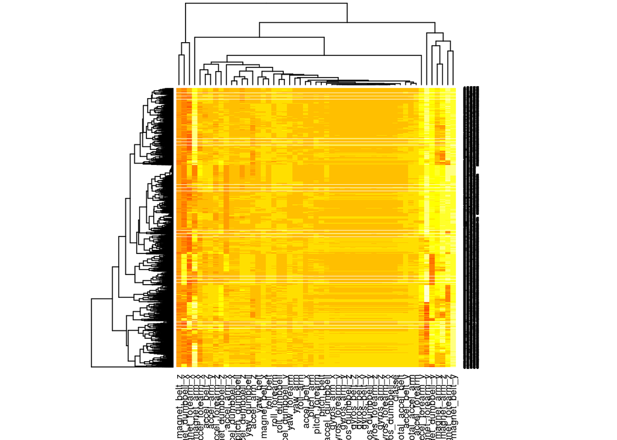